# Risk Factor Analysis

## Outcome Variable

**Outcome Variable:** stunted

## Predictor Variables

**Intervention Variable:** predfeed6

**Adjustment Set:**

- arm
- sex
- month
- brthmon
- W_mage
- meducyrs
- feducyrs
- hhwealth_quart
- hfoodsec
- W_mhtcm
- W_mwtkg
- W_mbmi
- vagbrth
- W_gagebrth
- W_birthwt
- W_birthlen
- W_nrooms
- W_nchldlt5
- W_parity
- impfloor
- impsan
- safeh20
- delta_W_mage
- delta_meducyrs
- delta_feducyrs
- delta_hhwealth_quart
- delta_hfoodsec
- delta_W_mhtcm
- delta_W_mwtkg
- delta_W_mbmi
- delta_vagbrth
- delta_W_gagebrth
- delta_W_birthwt
- delta_W_birthlen
- delta_W_nrooms
- delta_W_nchldlt5
- delta_W_parity
- delta_impfloor
- delta_impsan
- delta_safeh20

## Stratifying Variables

The analysis was stratified on these variable(s):

- agecat
- studyid
- country

## Data Summary

| agecat | studyid | country | predfeed6 | stunted | n_cell | n |
| --- | --- | --- | --- | --- | --- | --- |
| Birth | EE | PAKISTAN | 1 | 0 | 22 | 42 |
| Birth | EE | PAKISTAN | 1 | 1 | 16 | 42 |
| Birth | EE | PAKISTAN | 0 | 0 | 3 | 42 |
| Birth | EE | PAKISTAN | 0 | 1 | 1 | 42 |
| Birth | GMS-Nepal | NEPAL | 1 | 0 | 351 | 563 |
| Birth | GMS-Nepal | NEPAL | 1 | 1 | 68 | 563 |
| Birth | GMS-Nepal | NEPAL | 0 | 0 | 118 | 563 |
| Birth | GMS-Nepal | NEPAL | 0 | 1 | 26 | 563 |
| Birth | JiVitA-3 | BANGLADESH | 1 | 0 | 7012 | 13423 |
| Birth | JiVitA-3 | BANGLADESH | 1 | 1 | 3454 | 13423 |
| Birth | JiVitA-3 | BANGLADESH | 0 | 0 | 1967 | 13423 |
| Birth | JiVitA-3 | BANGLADESH | 0 | 1 | 990 | 13423 |
| Birth | JiVitA-4 | BANGLADESH | 1 | 0 | 1479 | 2632 |
| Birth | JiVitA-4 | BANGLADESH | 1 | 1 | 624 | 2632 |
| Birth | JiVitA-4 | BANGLADESH | 0 | 0 | 354 | 2632 |
| Birth | JiVitA-4 | BANGLADESH | 0 | 1 | 175 | 2632 |
| Birth | MAL-ED | BANGLADESH | 1 | 0 | 60 | 205 |
| Birth | MAL-ED | BANGLADESH | 1 | 1 | 12 | 205 |
| Birth | MAL-ED | BANGLADESH | 0 | 0 | 109 | 205 |
| Birth | MAL-ED | BANGLADESH | 0 | 1 | 24 | 205 |
| Birth | MAL-ED | BRAZIL | 1 | 0 | 4 | 60 |
| Birth | MAL-ED | BRAZIL | 1 | 1 | 2 | 60 |
| Birth | MAL-ED | BRAZIL | 0 | 0 | 47 | 60 |
| Birth | MAL-ED | BRAZIL | 0 | 1 | 7 | 60 |
| Birth | MAL-ED | INDIA | 1 | 0 | 2 | 39 |
| Birth | MAL-ED | INDIA | 1 | 1 | 2 | 39 |
| Birth | MAL-ED | INDIA | 0 | 0 | 29 | 39 |
| Birth | MAL-ED | INDIA | 0 | 1 | 6 | 39 |
| Birth | MAL-ED | NEPAL | 1 | 0 | 3 | 24 |
| Birth | MAL-ED | NEPAL | 1 | 1 | 0 | 24 |

[output cut: 114 more lines]

The following strata were considered:

- agecat: 24 months, studyid: EE, country: PAKISTAN
- agecat: 24 months, studyid: GMS-Nepal, country: NEPAL
- agecat: 24 months, studyid: JiVitA-3, country: BANGLADESH
- agecat: 24 months, studyid: JiVitA-4, country: BANGLADESH
- agecat: 24 months, studyid: LCNI-5, country: MALAWI
- agecat: 24 months, studyid: MAL-ED, country: BANGLADESH
- agecat: 24 months, studyid: MAL-ED, country: BRAZIL
- agecat: 24 months, studyid: MAL-ED, country: INDIA
- agecat: 24 months, studyid: MAL-ED, country: NEPAL
- agecat: 24 months, studyid: MAL-ED, country: PERU
- agecat: 24 months, studyid: MAL-ED, country: SOUTH AFRICA
- agecat: 24 months, studyid: MAL-ED, country: TANZANIA, UNITED REPUBLIC OF
- agecat: 6 months, studyid: EE, country: PAKISTAN
- agecat: 6 months, studyid: GMS-Nepal, country: NEPAL
- agecat: 6 months, studyid: JiVitA-3, country: BANGLADESH
- agecat: 6 months, studyid: JiVitA-4, country: BANGLADESH
- agecat: 6 months, studyid: LCNI-5, country: MALAWI
- agecat: 6 months, studyid: MAL-ED, country: BANGLADESH
- agecat: 6 months, studyid: MAL-ED, country: BRAZIL
- agecat: 6 months, studyid: MAL-ED, country: INDIA
- agecat: 6 months, studyid: MAL-ED, country: NEPAL
- agecat: 6 months, studyid: MAL-ED, country: PERU
- agecat: 6 months, studyid: MAL-ED, country: SOUTH AFRICA
- agecat: 6 months, studyid: MAL-ED, country: TANZANIA, UNITED REPUBLIC OF
- agecat: 6 months, studyid: SAS-FoodSuppl, country: INDIA
- agecat: Birth, studyid: EE, country: PAKISTAN
- agecat: Birth, studyid: GMS-Nepal, country: NEPAL
- agecat: Birth, studyid: JiVitA-3, country: BANGLADESH
- agecat: Birth, studyid: JiVitA-4, country: BANGLADESH
- agecat: Birth, studyid: MAL-ED, country: BANGLADESH
- agecat: Birth, studyid: MAL-ED, country: BRAZIL
- agecat: Birth, studyid: MAL-ED, country: INDIA
- agecat: Birth, studyid: MAL-ED, country: NEPAL
- agecat: Birth, studyid: MAL-ED, country: PERU
- agecat: Birth, studyid: MAL-ED, country: SOUTH AFRICA
- agecat: Birth, studyid: MAL-ED, country: TANZANIA, UNITED REPUBLIC OF

### Dropped Strata

Some strata were dropped due to rare outcomes:

- agecat: Birth, studyid: EE, country: PAKISTAN
- agecat: Birth, studyid: MAL-ED, country: BRAZIL
- agecat: Birth, studyid: MAL-ED, country: INDIA
- agecat: Birth, studyid: MAL-ED, country: NEPAL
- agecat: Birth, studyid: MAL-ED, country: SOUTH AFRICA
- agecat: Birth, studyid: MAL-ED, country: TANZANIA, UNITED REPUBLIC OF
- agecat: 6 months, studyid: EE, country: PAKISTAN
- agecat: 6 months, studyid: MAL-ED, country: BRAZIL
- agecat: 6 months, studyid: MAL-ED, country: INDIA
- agecat: 6 months, studyid: MAL-ED, country: NEPAL
- agecat: 6 months, studyid: MAL-ED, country: SOUTH AFRICA
- agecat: 6 months, studyid: MAL-ED, country: TANZANIA, UNITED REPUBLIC OF
- agecat: 6 months, studyid: SAS-FoodSuppl, country: INDIA
- agecat: 24 months, studyid: EE, country: PAKISTAN
- agecat: 24 months, studyid: MAL-ED, country: BRAZIL
- agecat: 24 months, studyid: MAL-ED, country: INDIA
- agecat: 24 months, studyid: MAL-ED, country: NEPAL
- agecat: 24 months, studyid: MAL-ED, country: SOUTH AFRICA
- agecat: 24 months, studyid: MAL-ED, country: TANZANIA, UNITED REPUBLIC OF

## Methods Detail

We’re interested in the causal parameters $E[Y_a]$ for all values of $a \in \mathcal{A}$. These parameters represent the mean outcome if, possibly contrary to fact, we intervened to set all units to have $A=a$. Under the randomization and positivity assumptions, these are identified by the statistical parameters $\psi_a=E_W[E_{Y|A,W}(Y|A=a,W)]$. In addition, we’re interested in the mean of $Y$, $E[Y]$ under no intervention (the observed mean). We will estimate these parameters by using SuperLearner to fit the relevant likelihood factors – $E_{Y|A,W}(Y|A=a,W)$ and $p(A=a|W)$, and then updating our likelihood fit using a joint TMLE.

For unadjusted analyses ($W=\{\}$), initial likelihoods were estimated using Lrnr_glm to estimate the simple $E(Y|A)$ and Lrnr_mean to estimate $p(A)$. For adjusted analyses, a small library containing Lrnr_glmnet, Lrnr_xgboost, and Lrnr_mean was used.

Having estimated these parameters, we will then use the delta method to estimate relative risks and attributable risks relative to a prespecified baseline level of $A$.

# Results Detail

## Results Plots

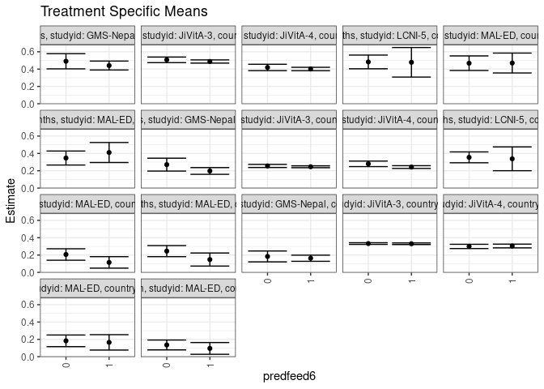

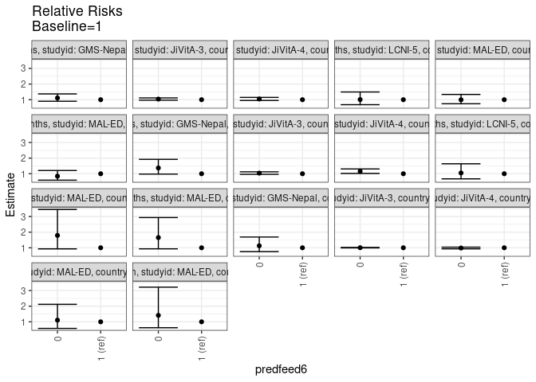

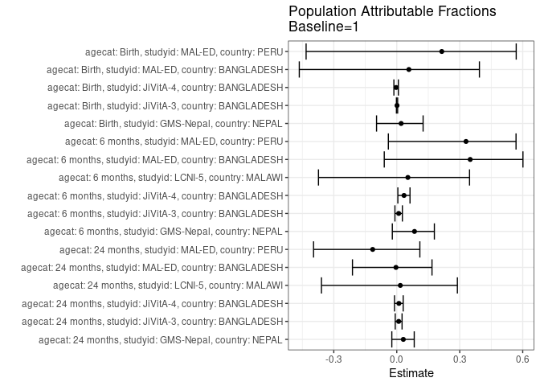

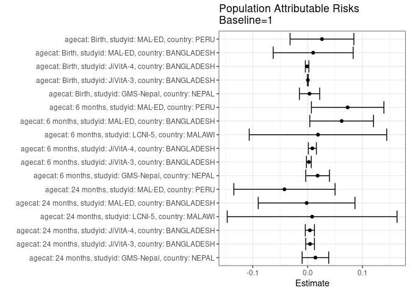

## Results Table

### Parameter: TSM

| agecat | studyid | country | intervention_level | baseline_level | estimate | ci_lower | ci_upper |
| --- | --- | --- | --- | --- | --- | --- | --- |
| Birth | GMS-Nepal | NEPAL | 1 | NA | 0.1634845 | 0.1281321 | 0.1988370 |
| Birth | GMS-Nepal | NEPAL | 0 | NA | 0.1842758 | 0.1213771 | 0.2471746 |
| Birth | JiVitA-3 | BANGLADESH | 1 | NA | 0.3306581 | 0.3214220 | 0.3398942 |
| Birth | JiVitA-3 | BANGLADESH | 0 | NA | 0.3326312 | 0.3228653 | 0.3423972 |
| Birth | JiVitA-4 | BANGLADESH | 1 | NA | 0.3044610 | 0.2829164 | 0.3260056 |
| Birth | JiVitA-4 | BANGLADESH | 0 | NA | 0.2997059 | 0.2750188 | 0.3243931 |
| Birth | MAL-ED | BANGLADESH | 1 | NA | 0.1654643 | 0.0769066 | 0.2540221 |
| Birth | MAL-ED | BANGLADESH | 0 | NA | 0.1833355 | 0.1162461 | 0.2504249 |
| Birth | MAL-ED | PERU | 1 | NA | 0.0958904 | 0.0281876 | 0.1635932 |
| Birth | MAL-ED | PERU | 0 | NA | 0.1357143 | 0.0788490 | 0.1925796 |
| 6 months | GMS-Nepal | NEPAL | 1 | NA | 0.1975120 | 0.1587081 | 0.2363159 |
| 6 months | GMS-Nepal | NEPAL | 0 | NA | 0.2705636 | 0.1962684 | 0.3448588 |
| 6 months | JiVitA-3 | BANGLADESH | 1 | NA | 0.2459824 | 0.2350474 | 0.2569174 |
| 6 months | JiVitA-3 | BANGLADESH | 0 | NA | 0.2556227 | 0.2376087 | 0.2736366 |
| 6 months | JiVitA-4 | BANGLADESH | 1 | NA | 0.2424860 | 0.2265299 | 0.2584421 |
| 6 months | JiVitA-4 | BANGLADESH | 0 | NA | 0.2797294 | 0.2479200 | 0.3115387 |
| 6 months | LCNI-5 | MALAWI | 1 | NA | 0.3377316 | 0.2004302 | 0.4750330 |
| 6 months | LCNI-5 | MALAWI | 0 | NA | 0.3546746 | 0.2919701 | 0.4173790 |
| 6 months | MAL-ED | BANGLADESH | 1 | NA | 0.1153923 | 0.0491505 | 0.1816342 |
| 6 months | MAL-ED | BANGLADESH | 0 | NA | 0.2066036 | 0.1405592 | 0.2726480 |
| 6 months | MAL-ED | PERU | 1 | NA | 0.1483752 | 0.0731461 | 0.2236042 |
| 6 months | MAL-ED | PERU | 0 | NA | 0.2453324 | 0.1814040 | 0.3092609 |
| 24 months | GMS-Nepal | NEPAL | 1 | NA | 0.4410726 | 0.3896026 | 0.4925427 |
| 24 months | GMS-Nepal | NEPAL | 0 | NA | 0.4902014 | 0.4025751 | 0.5778277 |
| 24 months | JiVitA-3 | BANGLADESH | 1 | NA | 0.4876557 | 0.4690063 | 0.5063050 |
| 24 months | JiVitA-3 | BANGLADESH | 0 | NA | 0.5066172 | 0.4743896 | 0.5388449 |
| 24 months | JiVitA-4 | BANGLADESH | 1 | NA | 0.4009747 | 0.3813156 | 0.4206337 |
| 24 months | JiVitA-4 | BANGLADESH | 0 | NA | 0.4188440 | 0.3820984 | 0.4555896 |
| 24 months | LCNI-5 | MALAWI | 1 | NA | 0.4785109 | 0.3080238 | 0.6489980 |
| 24 months | LCNI-5 | MALAWI | 0 | NA | 0.4827538 | 0.4036951 | 0.5618124 |
| 24 months | MAL-ED | BANGLADESH | 1 | NA | 0.4701037 | 0.3555496 | 0.5846577 |
| 24 months | MAL-ED | BANGLADESH | 0 | NA | 0.4680390 | 0.3841900 | 0.5518879 |
| 24 months | MAL-ED | PERU | 1 | NA | 0.4104106 | 0.2949123 | 0.5259088 |
| 24 months | MAL-ED | PERU | 0 | NA | 0.3465715 | 0.2657587 | 0.4273843 |

### Parameter: E(Y)

| agecat | studyid | country | intervention_level | baseline_level | estimate | ci_lower | ci_upper |
| --- | --- | --- | --- | --- | --- | --- | --- |
| Birth | GMS-Nepal | NEPAL | NA | NA | 0.1669627 | 0.1361293 | 0.1977961 |
| Birth | JiVitA-3 | BANGLADESH | NA | NA | 0.3310735 | 0.3218922 | 0.3402548 |
| Birth | JiVitA-4 | BANGLADESH | NA | NA | 0.3035714 | 0.2824097 | 0.3247332 |
| Birth | MAL-ED | BANGLADESH | NA | NA | 0.1756098 | 0.1233973 | 0.2278222 |
| Birth | MAL-ED | PERU | NA | NA | 0.1220657 | 0.0779993 | 0.1661322 |
| 6 months | GMS-Nepal | NEPAL | NA | NA | 0.2157221 | 0.1812209 | 0.2502233 |
| 6 months | JiVitA-3 | BANGLADESH | NA | NA | 0.2482578 | 0.2382387 | 0.2582768 |
| 6 months | JiVitA-4 | BANGLADESH | NA | NA | 0.2511704 | 0.2362353 | 0.2661055 |
| 6 months | LCNI-5 | MALAWI | NA | NA | 0.3566176 | 0.2995882 | 0.4136471 |
| 6 months | MAL-ED | BANGLADESH | NA | NA | 0.1774892 | 0.1281103 | 0.2268680 |
| 6 months | MAL-ED | PERU | NA | NA | 0.2214022 | 0.1718784 | 0.2709260 |
| 24 months | GMS-Nepal | NEPAL | NA | NA | 0.4553191 | 0.4102488 | 0.5003895 |
| 24 months | JiVitA-3 | BANGLADESH | NA | NA | 0.4921384 | 0.4750959 | 0.5091808 |
| 24 months | JiVitA-4 | BANGLADESH | NA | NA | 0.4050965 | 0.3867240 | 0.4234689 |
| 24 months | LCNI-5 | MALAWI | NA | NA | 0.4867725 | 0.4153250 | 0.5582200 |
| 24 months | MAL-ED | BANGLADESH | NA | NA | 0.4682927 | 0.3998183 | 0.5367670 |
| 24 months | MAL-ED | PERU | NA | NA | 0.3681592 | 0.3013164 | 0.4350020 |

### Parameter: RR

| agecat | studyid | country | intervention_level | baseline_level | estimate | ci_lower | ci_upper |
| --- | --- | --- | --- | --- | --- | --- | --- |
| Birth | GMS-Nepal | NEPAL | 1 | 1 | 1.0000000 | 1.0000000 | 1.000000 |
| Birth | GMS-Nepal | NEPAL | 0 | 1 | 1.1271758 | 0.7527874 | 1.687761 |
| Birth | JiVitA-3 | BANGLADESH | 1 | 1 | 1.0000000 | 1.0000000 | 1.000000 |
| Birth | JiVitA-3 | BANGLADESH | 0 | 1 | 1.0059674 | 0.9930552 | 1.019047 |
| Birth | JiVitA-4 | BANGLADESH | 1 | 1 | 1.0000000 | 1.0000000 | 1.000000 |
| Birth | JiVitA-4 | BANGLADESH | 0 | 1 | 0.9843821 | 0.9316244 | 1.040127 |
| Birth | MAL-ED | BANGLADESH | 1 | 1 | 1.0000000 | 1.0000000 | 1.000000 |
| Birth | MAL-ED | BANGLADESH | 0 | 1 | 1.1080061 | 0.5794774 | 2.118595 |
| Birth | MAL-ED | PERU | 1 | 1 | 1.0000000 | 1.0000000 | 1.000000 |
| Birth | MAL-ED | PERU | 0 | 1 | 1.4153061 | 0.6227136 | 3.216714 |
| 6 months | GMS-Nepal | NEPAL | 1 | 1 | 1.0000000 | 1.0000000 | 1.000000 |
| 6 months | GMS-Nepal | NEPAL | 0 | 1 | 1.3698591 | 0.9766891 | 1.921301 |
| 6 months | JiVitA-3 | BANGLADESH | 1 | 1 | 1.0000000 | 1.0000000 | 1.000000 |
| 6 months | JiVitA-3 | BANGLADESH | 0 | 1 | 1.0391908 | 0.9628456 | 1.121590 |
| 6 months | JiVitA-4 | BANGLADESH | 1 | 1 | 1.0000000 | 1.0000000 | 1.000000 |
| 6 months | JiVitA-4 | BANGLADESH | 0 | 1 | 1.1535899 | 1.0190813 | 1.305852 |
| 6 months | LCNI-5 | MALAWI | 1 | 1 | 1.0000000 | 1.0000000 | 1.000000 |
| 6 months | LCNI-5 | MALAWI | 0 | 1 | 1.0501671 | 0.6735666 | 1.637330 |
| 6 months | MAL-ED | BANGLADESH | 1 | 1 | 1.0000000 | 1.0000000 | 1.000000 |
| 6 months | MAL-ED | BANGLADESH | 0 | 1 | 1.7904450 | 0.9289821 | 3.450759 |
| 6 months | MAL-ED | PERU | 1 | 1 | 1.0000000 | 1.0000000 | 1.000000 |
| 6 months | MAL-ED | PERU | 0 | 1 | 1.6534604 | 0.9321917 | 2.932799 |
| 24 months | GMS-Nepal | NEPAL | 1 | 1 | 1.0000000 | 1.0000000 | 1.000000 |
| 24 months | GMS-Nepal | NEPAL | 0 | 1 | 1.1113848 | 0.9012825 | 1.370465 |
| 24 months | JiVitA-3 | BANGLADESH | 1 | 1 | 1.0000000 | 1.0000000 | 1.000000 |
| 24 months | JiVitA-3 | BANGLADESH | 0 | 1 | 1.0388831 | 0.9690414 | 1.113759 |
| 24 months | JiVitA-4 | BANGLADESH | 1 | 1 | 1.0000000 | 1.0000000 | 1.000000 |
| 24 months | JiVitA-4 | BANGLADESH | 0 | 1 | 1.0445647 | 0.9511393 | 1.147167 |
| 24 months | LCNI-5 | MALAWI | 1 | 1 | 1.0000000 | 1.0000000 | 1.000000 |
| 24 months | LCNI-5 | MALAWI | 0 | 1 | 1.0088668 | 0.6811794 | 1.494191 |
| 24 months | MAL-ED | BANGLADESH | 1 | 1 | 1.0000000 | 1.0000000 | 1.000000 |
| 24 months | MAL-ED | BANGLADESH | 0 | 1 | 0.9956079 | 0.7415138 | 1.336772 |
| 24 months | MAL-ED | PERU | 1 | 1 | 1.0000000 | 1.0000000 | 1.000000 |
| 24 months | MAL-ED | PERU | 0 | 1 | 0.8444507 | 0.5903044 | 1.208016 |

### Parameter: PAR

| agecat | studyid | country | intervention_level | baseline_level | estimate | ci_lower | ci_upper |
| --- | --- | --- | --- | --- | --- | --- | --- |
| Birth | GMS-Nepal | NEPAL | 1 | NA | 0.0034782 | -0.0150122 | 0.0219685 |
| Birth | JiVitA-3 | BANGLADESH | 1 | NA | 0.0004154 | -0.0005310 | 0.0013618 |
| Birth | JiVitA-4 | BANGLADESH | 1 | NA | -0.0008896 | -0.0041390 | 0.0023599 |
| Birth | MAL-ED | BANGLADESH | 1 | NA | 0.0101454 | -0.0628305 | 0.0831213 |
| Birth | MAL-ED | PERU | 1 | NA | 0.0261753 | -0.0319939 | 0.0843446 |
| 6 months | GMS-Nepal | NEPAL | 1 | NA | 0.0182101 | -0.0034576 | 0.0398778 |
| 6 months | JiVitA-3 | BANGLADESH | 1 | NA | 0.0022754 | -0.0021257 | 0.0066764 |
| 6 months | JiVitA-4 | BANGLADESH | 1 | NA | 0.0086844 | 0.0013757 | 0.0159932 |
| 6 months | LCNI-5 | MALAWI | 1 | NA | 0.0188861 | -0.1065252 | 0.1442974 |
| 6 months | MAL-ED | BANGLADESH | 1 | NA | 0.0620969 | 0.0039763 | 0.1202174 |
| 6 months | MAL-ED | PERU | 1 | NA | 0.0730271 | 0.0069252 | 0.1391290 |
| 24 months | GMS-Nepal | NEPAL | 1 | NA | 0.0142465 | -0.0099824 | 0.0384754 |
| 24 months | JiVitA-3 | BANGLADESH | 1 | NA | 0.0044827 | -0.0035162 | 0.0124816 |
| 24 months | JiVitA-4 | BANGLADESH | 1 | NA | 0.0041218 | -0.0042399 | 0.0124835 |
| 24 months | LCNI-5 | MALAWI | 1 | NA | 0.0082616 | -0.1466045 | 0.1631276 |
| 24 months | MAL-ED | BANGLADESH | 1 | NA | -0.0018110 | -0.0900246 | 0.0864026 |
| 24 months | MAL-ED | PERU | 1 | NA | -0.0422514 | -0.1345739 | 0.0500712 |

### Parameter: PAF

| agecat | studyid | country | intervention_level | baseline_level | estimate | ci_lower | ci_upper |
| --- | --- | --- | --- | --- | --- | --- | --- |
| Birth | GMS-Nepal | NEPAL | 1 | NA | 0.0208319 | -0.0963320 | 0.1254747 |
| Birth | JiVitA-3 | BANGLADESH | 1 | NA | 0.0012548 | -0.0016083 | 0.0041097 |
| Birth | JiVitA-4 | BANGLADESH | 1 | NA | -0.0029303 | -0.0136851 | 0.0077103 |
| Birth | MAL-ED | BANGLADESH | 1 | NA | 0.0577725 | -0.4643405 | 0.3937252 |
| Birth | MAL-ED | PERU | 1 | NA | 0.2144362 | -0.4318688 | 0.5690175 |
| 6 months | GMS-Nepal | NEPAL | 1 | NA | 0.0844147 | -0.0212033 | 0.1791092 |
| 6 months | JiVitA-3 | BANGLADESH | 1 | NA | 0.0091653 | -0.0087252 | 0.0267385 |
| 6 months | JiVitA-4 | BANGLADESH | 1 | NA | 0.0345759 | 0.0051718 | 0.0631109 |
| 6 months | LCNI-5 | MALAWI | 1 | NA | 0.0529589 | -0.3729321 | 0.3467362 |
| 6 months | MAL-ED | BANGLADESH | 1 | NA | 0.3498628 | -0.0595794 | 0.6010885 |
| 6 months | MAL-ED | PERU | 1 | NA | 0.3298389 | -0.0400623 | 0.5681836 |
| 24 months | GMS-Nepal | NEPAL | 1 | NA | 0.0312891 | -0.0235538 | 0.0831935 |
| 24 months | JiVitA-3 | BANGLADESH | 1 | NA | 0.0091086 | -0.0072741 | 0.0252249 |
| 24 months | JiVitA-4 | BANGLADESH | 1 | NA | 0.0101748 | -0.0106562 | 0.0305765 |
| 24 months | LCNI-5 | MALAWI | 1 | NA | 0.0169722 | -0.3587038 | 0.2887752 |
| 24 months | MAL-ED | BANGLADESH | 1 | NA | -0.0038672 | -0.2110375 | 0.1678627 |
| 24 months | MAL-ED | PERU | 1 | NA | -0.1147638 | -0.3963239 | 0.1100214 |